# Meta-analysis in R

A worked example: BCG vaccine and tuberculosis (13 RCTs)

Dr Gurpreet

2026-11-18

# The question and the data

## The data: 13 trials of BCG vaccine

| Study | Latitude (°) | Allocation | Vaccinated: TB / N | Control: TB / N |
| --- | --- | --- | --- | --- |
| Aronson, 1948 | 44 | Random | 4 / 123 | 11 / 139 |
| Ferguson & Simes, 1949 | 55 | Random | 6 / 306 | 29 / 303 |
| Rosenthal et al, 1960 | 42 | Random | 3 / 231 | 11 / 220 |
| Hart & Sutherland, 1977 | 52 | Random | 62 / 13,598 | 248 / 12,867 |
| Frimodt-Moller et al, 1973 | 13 | Alternate | 33 / 5,069 | 47 / 5,808 |
| Stein & Aronson, 1953 | 44 | Alternate | 180 / 1,541 | 372 / 1,451 |
| Vandiviere et al, 1973 | 19 | Random | 8 / 2,545 | 10 / 629 |
| TPT Madras, 1980 | 13 | Random | 505 / 88,391 | 499 / 88,391 |
| Coetzee & Berjak, 1968 | 27 | Random | 29 / 7,499 | 45 / 7,277 |
| Rosenthal et al, 1961 | 42 | Systematic | 17 / 1,716 | 65 / 1,665 |
| Comstock et al, 1974 | 18 | Systematic | 186 / 50,634 | 141 / 27,338 |
| Comstock & Webster, 1969 | 33 | Systematic | 5 / 2,498 | 3 / 2,341 |
| Comstock et al, 1976 | 33 | Systematic | 27 / 16,913 | 29 / 17,854 |

**PICO:** Population = people in 13 trial settings · Intervention = BCG · Comparator = no vaccine · Outcome = TB cases. Trial sizes range from 262 to 176,782 participants, and sites span 13° to 55° latitude.

## Step 1: Effect size for each trial

| Study | RR | 95% CI |
| --- | --- | --- |
| Aronson, 1948 | 0.41 | 0.13 to 1.26 |
| Ferguson & Simes, 1949 | 0.20 | 0.09 to 0.49 |
| Rosenthal et al, 1960 | 0.26 | 0.07 to 0.92 |
| Hart & Sutherland, 1977 | 0.24 | 0.18 to 0.31 |
| Frimodt-Moller et al, 1973 | 0.80 | 0.52 to 1.25 |
| Stein & Aronson, 1953 | 0.46 | 0.39 to 0.54 |
| Vandiviere et al, 1973 | 0.20 | 0.08 to 0.50 |
| TPT Madras, 1980 | 1.01 | 0.89 to 1.14 |
| Coetzee & Berjak, 1968 | 0.63 | 0.39 to 1.00 |
| Rosenthal et al, 1961 | 0.25 | 0.15 to 0.43 |
| Comstock et al, 1974 | 0.71 | 0.57 to 0.89 |
| Comstock & Webster, 1969 | 1.56 | 0.37 to 6.53 |
| Comstock et al, 1976 | 0.98 | 0.58 to 1.66 |

**How to read**

Risk ratio (RR) = risk of TB in vaccinated ÷ risk in controls. RR < 1 means the vaccine protects. We analyse **log RR** and back-transform for display.

**What we infer**

RRs range from 0.20 to 1.56. Most trials favour BCG, but by very different amounts: the first hint of **heterogeneity**.

# Pooling the trials

## Step 2: Common-effect vs random-effects

| Model | Pooled RR (95% CI) | 95% prediction interval |
| --- | --- | --- |
| Common effect | 0.65 (0.60 to 0.70) | — |
| Random effects | 0.49 (0.34 to 0.70) | 0.15 to 1.55 |

**How to read**

*Common effect* assumes all trials estimate one true RR. *Random effects* assumes true RRs vary between settings and estimates their **average**. The prediction interval is where a **new** trial’s true RR is likely to fall.

**What we infer**

BCG reduces TB risk by about **51%** on average (RR 0.49). The common-effect CI is falsely narrow because it ignores between-trial variation. The prediction interval (0.15 to 1.55) **crosses 1**.

## Step 3: Forest plot

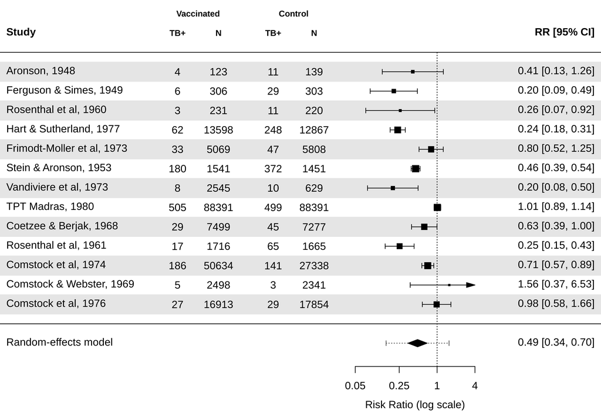

**Square** = trial’s RR, size = weight. **Line** = its 95% CI.

**Vertical line at 1** = no effect. Left favours BCG.

**Diamond** = pooled RR and CI. **Dotted line** = prediction interval.

**x-axis is log scale:** 0.5 and 2 are equally far from 1.

## Forest plot: what we infer

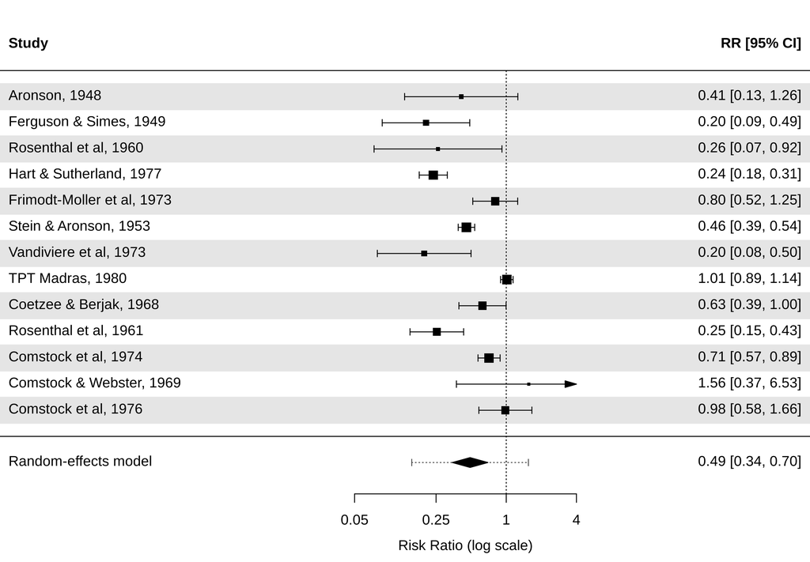

**Direction:** 11 of 13 trials favour BCG.

**Precision:** several trials are non-significant alone, yet the pooled RR 0.49 (0.34 to 0.70) is clearly below 1.

**Heterogeneity by eye:** CIs often do not overlap (Hart & Sutherland 0.24 vs TPT Madras 1.01).

**Weights are even** (4–10%). Under common effect, TPT Madras alone would take 41%.

# Heterogeneity

## Step 4: How much do the trials disagree?

| Statistic | Estimate | 95% CI |
| --- | --- | --- |
| Cochran’s Q (df = 12) | 152.23 | p < 0.0001 |
| τ² | 0.31 | 0.12 to 1.11 |
| τ | 0.56 | 0.35 to 1.05 |
| I² (%) | 92.22 | 81.92 to 97.68 |
| H² | 12.86 | 5.53 to 43.07 |

**How to read**

**Q** tests “all trials share one effect”. **I²** = share of variability due to real differences (a proportion). **τ²** = between-trial variance on the log RR scale (an absolute amount).

**What we infer**

I² = **92%**: almost all the spread is real, not chance. Even the lower CI bound (82%) is high. Pooling is still fine, but we must **explain** the heterogeneity.

## Step 5: Meta-regression on latitude

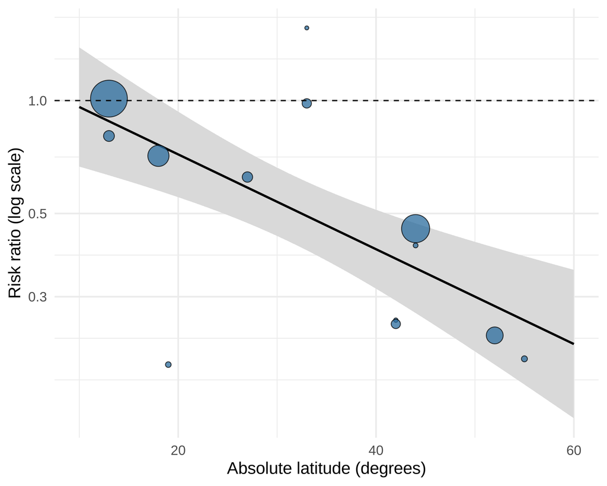

**How to read**

Bubble = trial (size = weight). Line and band = fitted relation and its 95% CI. Dashed line = no effect. A **slope** means the moderator explains heterogeneity.

**What we infer**

Each degree from the equator multiplies RR by 0.97. Little effect near the equator; strong protection above 50°. Latitude explains **76%** of τ²; I² falls from 92% to 68%.

Across-study (ecological) association. Latitude is a proxy, e.g. for exposure to environmental mycobacteria.

# Small-study effects

## Step 6: Funnel plots

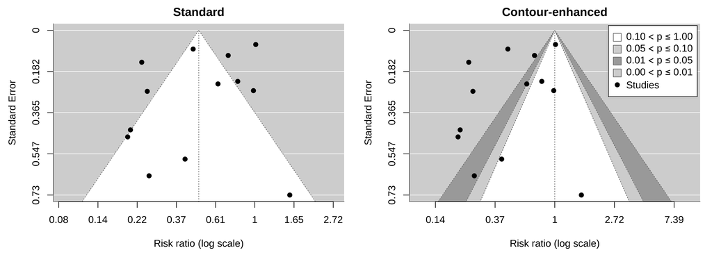

**How to read:** effect (x) vs standard error (y, inverted: big trials at top). Expect a symmetric funnel; a gap in a bottom corner suggests missing small trials. Grey zones = statistically significant results.

**What we infer:** large trials are spread widely (heterogeneity, not bias). Small trials sit in both shaded and white zones, so only a mild hint of asymmetry and no clear sign of missing null trials.

## Step 7: Egger’s test and trim-and-fill

| Test | Result |
| --- | --- |
| Egger’s regression | t = -1.40, p = 0.19 |
| Begg’s rank correlation | Kendall’s τ = 0.03, p = 0.95 |
| Trim-and-fill: studies imputed | 1 (right side) |
| Trim-and-fill: adjusted RR | 0.52 (0.37 to 0.74) |

**How to read:** Egger tests whether small trials give systematically different results. Trim-and-fill imputes “missing” trials (open circles) and re-pools.

Use these tests only with ≥ 10 studies. Asymmetry ≠ publication bias: heterogeneity alone can distort a funnel.

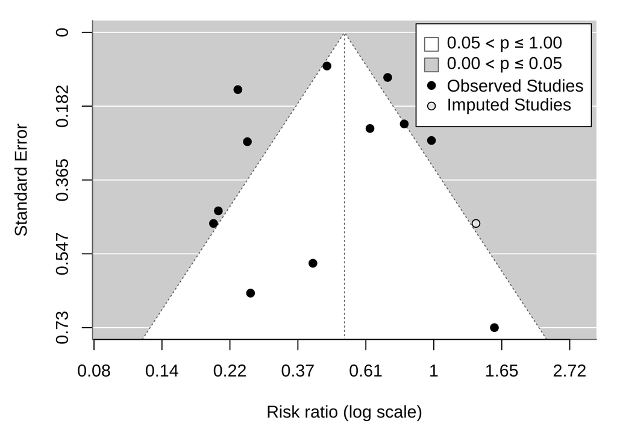

**What we infer:** no strong evidence of small-study effects. Adjusting moves RR only from 0.49 to 0.52.

# Sensitivity analysis

## Step 8: Leave-one-out

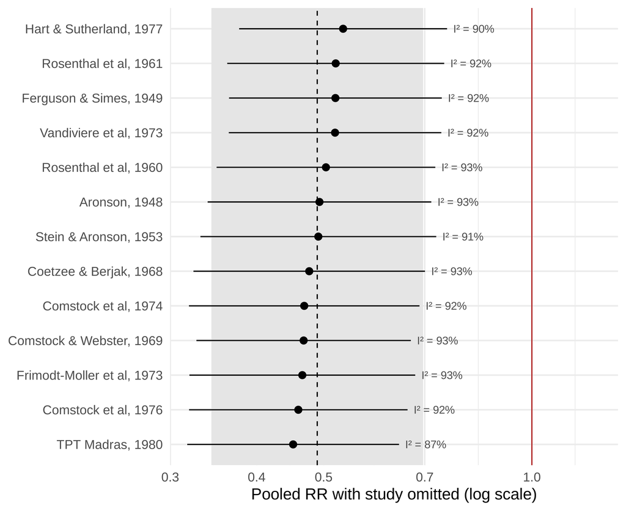

**How to read**

Each row = re-analysis without that trial. Dashed line and band = original RR and CI. Red line = no effect. Labels = I² after removal.

**What we infer**

I² stays above 85% whatever is removed: heterogeneity is **not one outlier**.

## Step 9: Influence diagnostics

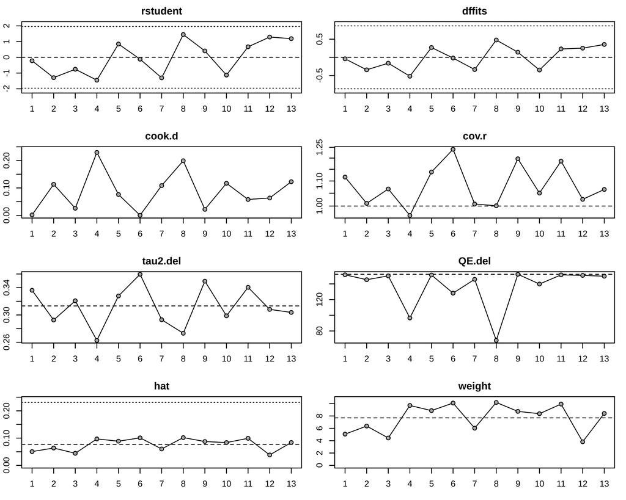

**How to read**

One dot per trial. **rstudent** beyond ±2 = outlier. **cook.d / dffits** = shift in pooled result if removed. **QE.del** = Q after removal. **Red** = flagged as influential.

**What we infer**

**0 trials flagged.** Hart & Sutherland (Cook’s d 0.23) and TPT Madras (0.20) matter most; removing them cuts Q from 152 to 97 and 68.

## Step 10: Baujat plot

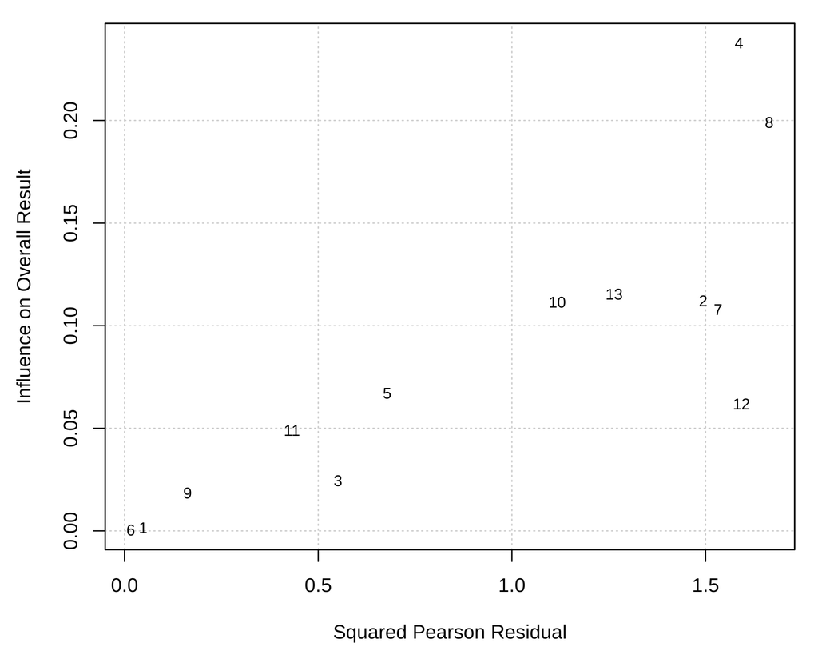

**How to read**

x = contribution to heterogeneity. y = influence on the pooled result. **Top-right** trials do both and deserve a closer look.

**What we infer**

Trials 4 (Hart & Sutherland, 52°) and 8 (TPT Madras, 13°) sit top-right, at **opposite latitudes**: the same story as the meta-regression.

# Summary

## Results at a glance

[output not shown]

## Take-home messages

**1.** BCG reduces TB risk by about **half** on average (RR 0.49).

**2.** Heterogeneity is **very high** (I² 92%). Always report the **prediction interval**, not only the CI.

**3.** Look for **why** trials differ: latitude explains about three-quarters of it.

**4.** Funnel asymmetry ≠ publication bias. Here there is no strong evidence of small-study effects.

**5.** Sensitivity analyses show the conclusion does **not** rest on any single trial.